# Homework 05

## Question 5: Create a plot-formatting skill

Create a short `SKILL.md` file for improving the formatting of STAT 432 homework plots. You may use AI to help write it.

1. Include a title, a description, and a few formatting rules. The description should limit the skill to STAT 432 homework plot improvements and require an explicit request to use it. Your rules should address margins, titles, axes, labels, colors, and sizes for plots produced in R or Python. Keep them portable: do not refer to specific homework questions.

• Solution:

```markdown
---
name: stat432-plot-formatting
description: Improve the appearance and readability of STAT 432 homework plots only when the user explicitly asks to use this skill.
---

# STAT 432 Plot Formatting

- Keep the original data, calculations, statistical results, and meaning unchanged.
- Set margins so titles, axis labels, tick labels, and legends are fully visible and not crowded.
- Use concise titles that clearly describe what the plot shows.
- Make axes easy to read with clear labels, appropriate limits, and sensible tick spacing.
- Use descriptive axis labels and include measurement units when they are relevant.
- Use distinct, readable colors when comparing multiple curves or groups, while keeping the overall appearance simple.
- Choose text, point, and line sizes that remain readable when the plot is displayed in a homework document.
- Use a moderate figure size that fits naturally in an R Markdown or Python document without being too large or too small.
- Keep legends readable and place them where they do not cover important parts of the plot.
- Apply these improvements to the user's existing R or Python plotting code without changing the underlying analysis.
```

2. Ask your agent to install the skill. Explicitly call it to improve the plot from Question 1, then compare the original and revised versions. Do you like the changes? You may revise the skill and test it a couple more times, or uninstall it if it remains unhelpful.

• Solution:

I installed `stat432-plot-formatting` and explicitly asked the agent to use it on the bias–variance plot from Question 1. The simulation results below are unchanged; only the presentation is revised.

### Original version

**Show the workflow**

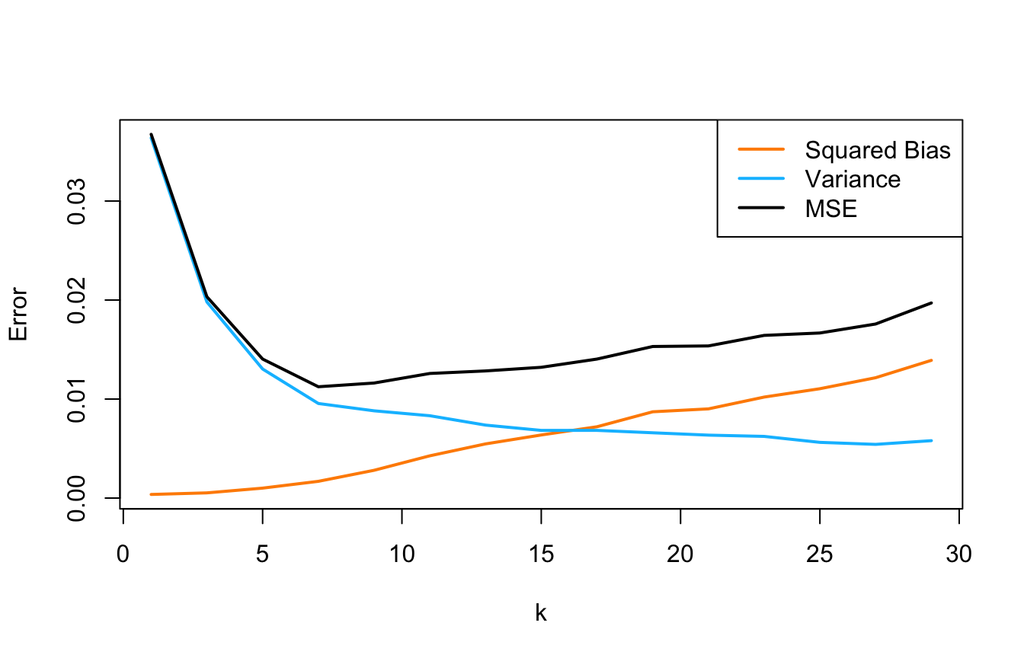

```r
plot(
  k.values, bias.squared,
  type = "l", lwd = 2,
  col = "darkorange",
  xlab = "k",
  ylab = "Error",
  ylim = range(c(bias.squared, variance, mse))
)

lines(k.values, variance,
      lwd = 2, col = "deepskyblue")

lines(k.values, mse,
      lwd = 2, col = "black")

legend(
  "topright",
  legend = c("Squared Bias", "Variance", "MSE"),
  col = c("darkorange", "deepskyblue", "black"),
  lty = 1,
  lwd = 2
)
```

### Revised version

**Show the workflow**

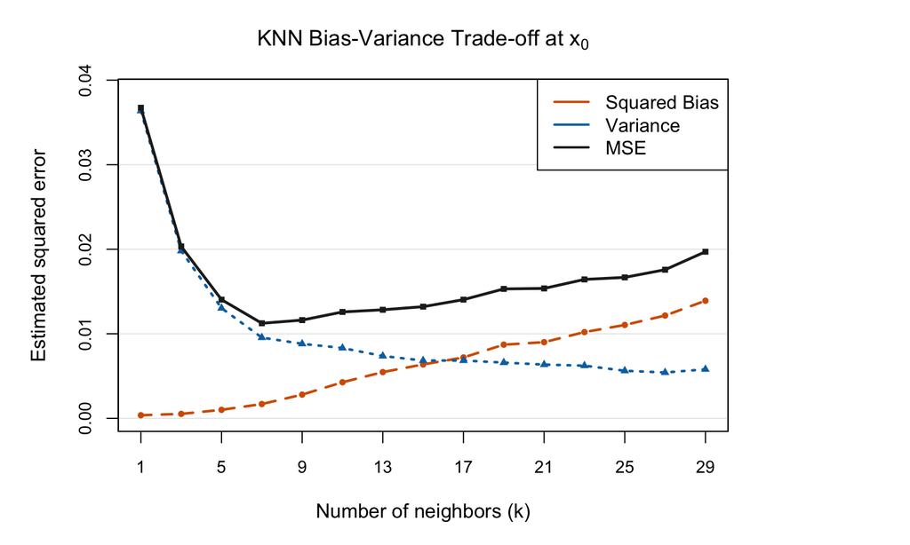

```r
old.par = par(no.readonly = TRUE)
par(mar = c(5.0, 5.2, 3.5, 8.0))

plot(
  k.values, bias.squared,
  type = "n",
  xlab = "Number of neighbors (k)",
  ylab = "Estimated squared error",
  main = expression("KNN Bias-Variance Trade-off at " * x[0]),
  xaxt = "n",
  ylim = c(0, max(mse) * 1.05),
  cex.main = 1.15,
  cex.lab = 1.05,
  cex.axis = 0.9
)

axis(1, at = seq(1, 29, by = 4), cex.axis = 0.9)
abline(h = pretty(c(0, max(mse))), col = "grey90", lwd = 0.8)

lines(k.values, bias.squared,
      type = "o", pch = 16, lty = 2, lwd = 2.2,
      cex = 0.75, col = "#D55E00")

lines(k.values, variance,
      type = "o", pch = 17, lty = 3, lwd = 2.2,
      cex = 0.75, col = "#0072B2")

lines(k.values, mse,
      type = "o", pch = 15, lty = 1, lwd = 2.4,
      cex = 0.7, col = "#222222")

legend(
  "topright",
  legend = c("Squared Bias", "Variance", "MSE"),
  col = c("#D55E00", "#0072B2", "#222222"),
  lty = 1,
  lwd = 2
)

box()
```

**Show the workflow**

```r
par(old.par)
```

3. Append your final `SKILL.md` content to your submission and briefly explain your choices and experience.

• Solution:

```markdown
---
name: stat432-plot-formatting
description: Improve the appearance and readability of STAT 432 homework plots only when the user explicitly asks to use this skill.
---

# STAT 432 Plot Formatting

- Keep the original data, calculations, statistical results, and meaning unchanged.
- Set margins so titles, axis labels, tick labels, and legends are fully visible and not crowded.
- Use concise titles that clearly describe what the plot shows.
- Make axes easy to read with clear labels, appropriate limits, and sensible tick spacing.
- Use descriptive axis labels and include measurement units when they are relevant.
- Use distinct, readable colors when comparing multiple curves or groups, while keeping the overall appearance simple.
- Choose text, point, and line sizes that remain readable when the plot is displayed in a homework document.
- Use a moderate figure size that fits naturally in an R Markdown or Python document without being too large or too small.
- Keep legends readable and place them where they do not cover important parts of the plot.
- Apply these improvements to the user's existing R or Python plotting code without changing the underlying analysis.
```

I limited the skill to STAT 432 homework plots and required an explicit request so that it does not change plots during unrelated work. The rules focus on readability while protecting the statistical content: the data, calculations, and meaning must remain unchanged. I also kept the instructions portable so they can be applied to either R or Python plotting code.